# DV_RProject2: Visualizations From Narcisstic Personality Inventory (NPI) Test

Syairah Ridzuan, Madeline Packard, Arthur DeVitalis

February 16, 2015

The Narcisstic Personality Inventory (NPI) test is created by Raskin and Hall (1979) and it is designed to evaluate narcisstic expressions frequently conveyed in normal circumstances. It is important to note that those who obtain high scores in this test are not necessarily diagnosed with Narcisstic Personality Disorder (NPD).

**Pulling the Data Set from Oracle Database**

The data set pulled from the Oracle database includes participants’ answers to all forty questions, along with participant’s age, gender, time taken to complete the test, and participants’ score on the test.

```r
source("../01 Data/full_df.R", echo = TRUE)
```

```
##
## > npi_df <- data.frame(eval(parse(text = substring(getURL(URLencode("http://129.152.144.84:5001/rest/native/?query=\"SELECT score, Q1, Q2, Q3, Q4, Q5, .... [TRUNCATED]
##
## > npi_df %>% tbl_df
## Source: local data frame [11,236 x 44]
##
##    SCORE Q1 Q2 Q3 Q4 Q5 Q6 Q7 Q8 Q9 Q10 Q11 Q12 Q13 Q14 Q15 Q16 Q17 Q18
## 1      5  2  2  2  1  1  2  1  2  1   1   1   2   2   2   1   2   2   1
## 2     36  1  1  2  2  2  1  2  1  2   2   1   1   1   1   2   1   1   2
## 3      2  2  2  2  1  1  2  1  2  1   1   2   2   2   2   1   1   1   1
## 4     27  1  1  1  1  2  1  2  1  2   2   2   2   1   2   2   1   1   2
## 5      4  1  2  2  1  1  2  1  2  1   1   2   2   2   2   1   1   1   1
## 6     10  1  2  2  1  2  2  1  2  1   2   1   1   2   2   1   2   1   1
## 7      6  1  2  2  1  1  1  1  2  1   1   1   1   2   2   1   1   1   1
## 8      9  2  2  2  1  1  2  2  1  1   1   1   2   2   2   1   2   1   1
## 9      4  2  2  2  1  2  2  1  2  1   1   2   2   2   2   2   2   1   1
## 10    14  1  2  2  2  2  2  1  1  1   2   1   2   2   2   1   1   2   1
## ..   ... .. .. .. .. .. .. .. .. .. ... ... ... ... ... ... ... ... ...
## Variables not shown: Q19 (dbl), Q20 (dbl), Q21 (dbl), Q22 (dbl), Q23
##   (dbl), Q24 (dbl), Q25 (dbl), Q26 (dbl), Q27 (dbl), Q28 (dbl), Q29 (dbl),
##   Q30 (dbl), Q31 (dbl), Q32 (dbl), Q33 (dbl), Q34 (dbl), Q35 (dbl), Q36
##   (dbl), Q37 (dbl), Q38 (dbl), Q39 (dbl), Q40 (dbl), ELAPSE (fctr), GENDER
##   (dbl), AGE (dbl)
```

The data set is too large to display all 44 columns in this HTML document, thus the following shows a subset of the dataframe that are just loaded into R.

```r
source("../01 Data/display_subset.R", echo = TRUE)
```

```
##
## > npi_df %>% select(score, Q1, Q2, Q3, Q4, Q5, Q16,
## +     Q17, Q18, Q19, Q20, elapse, gender, age) %>% tbl_df
## Source: local data frame [11,236 x 14]
##
##    score Q1 Q2 Q3 Q4 Q5 Q16 Q17 Q18 Q19 Q20 elapse gender age
## 1      5  2  2  2  1  1   2   2   1   1   1    350      1  46
## 2     36  1  1  2  2  2   1   1   2   2   2    263      1  39
## 3      2  2  2  2  1  1   1   1   1   1   1    157      2  30
## 4     27  1  1  1  1  2   1   1   2   2   2    238      1  30
## 5      4  1  2  2  1  1   1   1   1   1   1    714      1  40
## 6     10  1  2  2  1  2   2   1   1   2   1    272      1  31
## 7      6  1  2  2  1  1   1   1   1   1   1    292      1  54
## 8      9  2  2  2  1  1   2   1   1   1   2    198      1  32
## 9      4  2  2  2  1  2   2   1   1   2   1    144      1  22
## 10    14  1  2  2  2  2   1   2   1   1   1    244      1  44
## ..   ... .. .. .. .. .. ... ... ... ... ...    ...    ... ...
```

### Visualizations

Once we have the data loaded from oracle, we begin visualizing different data subsets. One interesting observation would be to see the distribution of scores across the number of participants.

```r
source("../02 Visualizations/score_dist.R", echo = TRUE)
```

```
##
## > npi_df %>% ggplot(aes(score)) + geom_histogram(binwidth = 1,
## +     fill = "brown", color = "pink") + xlab("Participants' Score (Score)") +
## +     y .... [TRUNCATED]
```

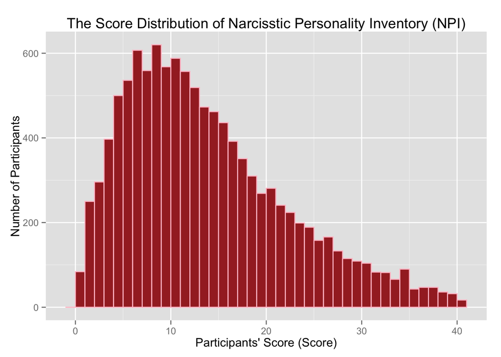

The distribution above shows that participants score 13 on average in the test. The median score is slightly lower than mean, which is 12.

We proceeded to explore the existence of any correlation between factors like age and gender with narcisstic expressions and tendencies.

```r
source("../02 Visualizations/tendency_by_age_gender.R", echo = TRUE)
```

```
##
## > npi_df %>% group_by(score, age, gender) %>% ggplot(aes(x = age,
## +     y = score, color = gender)) + geom_point() + facet_wrap(~gender) +
## +     xla .... [TRUNCATED]
```

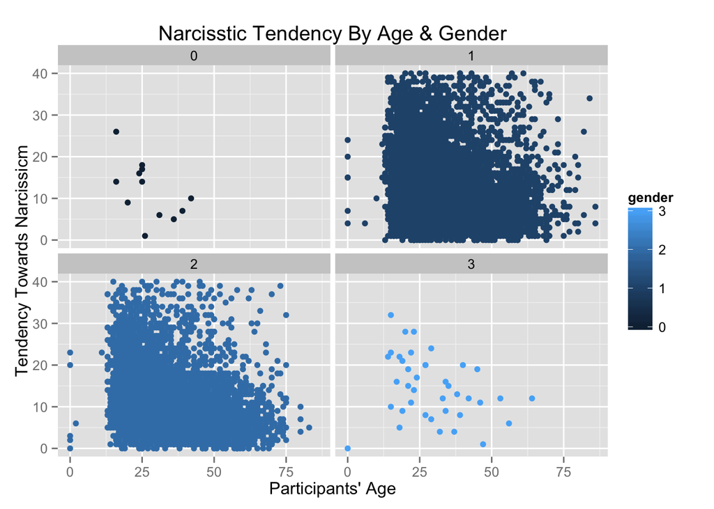

In this graph, gender is identified as: 0 = Not Identified, 1 = Male, 2 = Female, 3 = Other.

The plot shows that overall narcissim decreases slightly with age, regardless of gender. The negative correlation shows narcissistic expressions appears to be more frequent with the younger generation.

The boxplot below displays much clearly relationship between gender and score.

```
##
## > boxplot(score ~ gender, data = npi_df, xlab = "gender",
## +     names = c("0 - No Gender", "1 - Male", "2 - Female", "3 - Other"),
## +     ylab = "Par ..." ... [TRUNCATED]
```

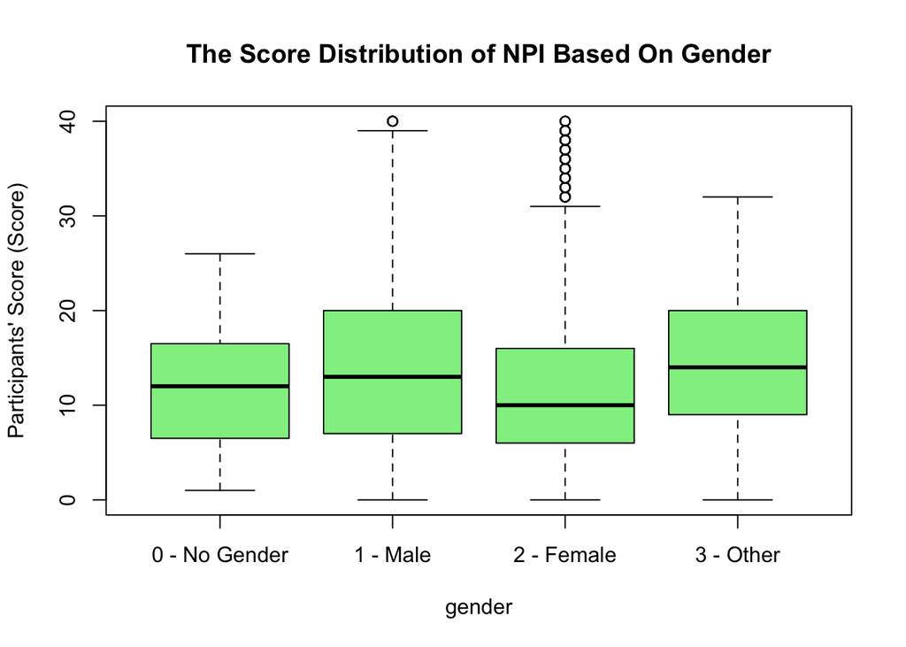

```r
source("../02 Visualizations/boxplot_score_gender.R", echo = TRUE)
```

Comparing the boxplots, men have higher median NPI score compared to women. In fact, 50% of women have NPI score that 10 or less. Men also has a wider distribution of NPI score compared to women as well the other two gender classifications, although women have a lot of scores that are outliers.

```r
source("../01 Data/modified_df.R", echo = TRUE)
```

```
##
## > mdf <- melt(npi_df, id = c("score", "elapse", "age",
## +     "gender"))
```

The bar graphs below display the responses for all the questions in the NPI test.

```r
source("../02 Visualizations/participants_response_allQs.R", echo = TRUE)
```

```
##
## > mdf %>% ggplot(aes(x = value, color = value)) + geom_bar() +
## +     facet_wrap(~variable) + xlab("Type of Response") + ylab("Number of Participants" .... [TRUNCATED]
```

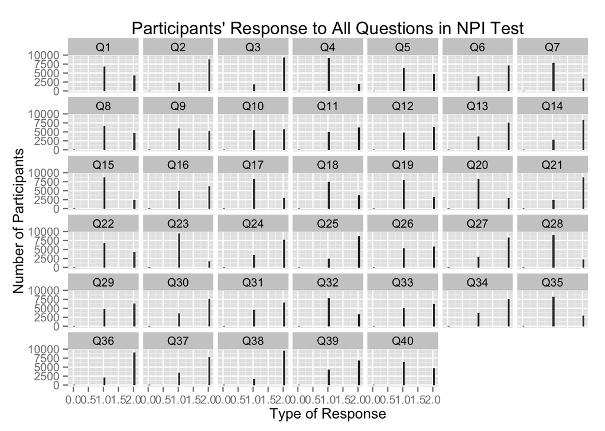

We’re interested to see what kind of questions received many non-responses, which is indicated by 0 on the x-axis. However, notice that the scale on the y-axis is too large thus preventing us from viewing the nonresponses.

A better way to do this would be only to view all the records that contain the nonresponses. Hence, we took a subset of the modified dataframe to help visualize the results.

```r
source("../01 Data/subsetof_modified_df.R", echo = TRUE)
```

```
##
## > unanswered_mdf <- subset(mdf, value == 0)
```

Then, we did a preliminary visualization of the non-responses for all the questions by creating the following bar graph:

```r
source("../02 Visualizations/allquestions_nonresponse.R", echo = TRUE)
```

```
##
## > unanswered_mdf %>% ggplot(aes(x = variable)) + geom_bar()
```

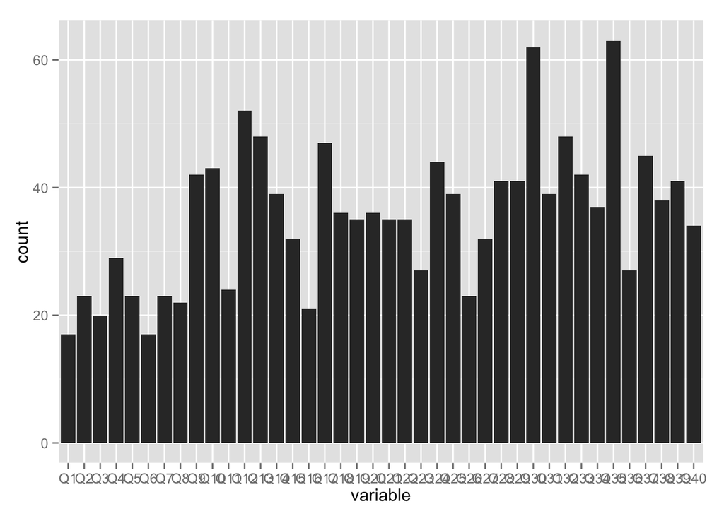

Based on the graph above, questions 35, 30, and 12 are among the questions that received the most nonresponse.

The following are the questions:

- Q12 1 = I like to have authority over other people. 2 = I don’t mind following orders.
- Q30 1 = I really like to be the center of attention. 2 = It makes me uncomfortable to be the center of attention.
- Q35 1 = People sometimes believe what I tell them. 2 = I can make anybody believe anything I want them to.

We are curious about the non-responses by gender so we plot the bar graph below. It is important to note that there is not a graph for gender = 0. This happens to be the case because the participants who did not identify their gender chose to answer all the questions in the test (which is either response 1 or two).

```r
source("../02 Visualizations/nonresponse_bygender.R", echo = TRUE)
```

```
##
## > unanswered_mdf %>% ggplot(aes(variable, fill = variable)) +
## +     geom_bar(fill = "#FF6666", colour = "black") + facet_grid(gender ~
## +     .) + xl .... [TRUNCATED]
```

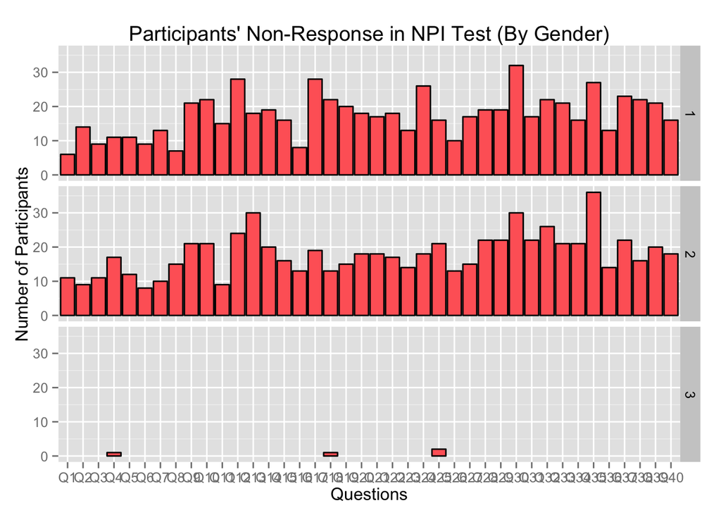

Both males and females had a high rate of non-response on question 35, but almost 40 women avoided from specifying their answer to the question compared to 26 men:

- Q35 1 = People sometimes believe what I tell them. 2 = I can make anybody believe anything I want them to.

Men were less significantly responsive compared to women on these questions:

- Q11 1 = I am assertive. 2 = I wish I were more assertive.
- Q17 1 = If I feel competent I am willing to take responsibility for making decisions. 2 = I like to take responsibility for making decisions.
- Q24 1 = I expect a great deal from other people. 2 = I like to do things for other people.

Another quite interesting visualization is the relationship between time elapse and NPI scores of all participants regardless of age and gender. This visualization is constructed from the original data set, npi_df.

```
##
## > npi_df$score <- as.factor(npi_df$score)
##
## > npi_df$elapse <- as.numeric(npi_df$elapse)
##
## > boxplot(elapse ~ score, data = npi_df, xlab = "Participants' Score (Score)",
## +     ylab = "Time Taken to Complete NPI Test", main = "Narcisstic Ten ..." ... [TRUNCATED]
```

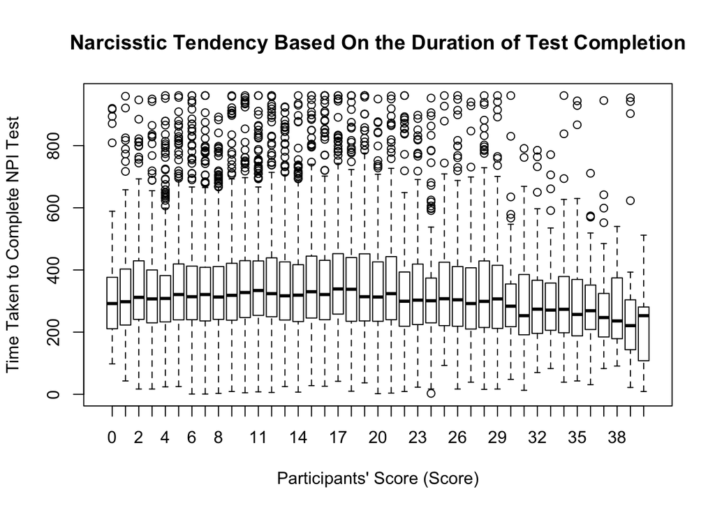

```r
source("../02 Visualizations/boxplot_score_elapse.R", echo = TRUE)
```

The comparison between the boxplots’ width as well as the width of the distributions seem to suggest people with significantly higher NPI scores ( >35) take less time to complete the test. It is also interesting to see that there are a lot of outliers for lower NPI scores (<25); this exceeds the suggested time completion by Raskin and Hall which is between 5 to 10 minutes (300s <elapse < 600s).

Note : For more information about the NPI, please read codebook.txt located in `01 Data` folder as well as visit the website at which this test is conducted (http://personality-testing.info/tests/NPI.php)